# Osnovno o kursu

- Mitrovic Kristijan, email: kristijan.mitrovic@code.edu.rs
- Predavanja ponedeljkom i cetvrtkom, od 17:30 - 21:00, po 4 skolska casa (1.5h predavanja, 0.5h pauza, 1.5h predavanja)
- Teorijska predavanja i praktican rad
- Na pocetku svakog casa recap sta je radjeno prosli put
- Domaci zadaci za rad od kuce
- Evidencija prisustva i rada tokom kursa
- Dva testa tokom kursa
- Finalni test na kraju kursa
- Domace zadatke treba poslati **pre pocetka** sledeceg casa na mejl, sa subject-om: **Domaci zadatak X - Ime Prezime**, gde umesto X treba navesti redni broj domaceg (a bice ih manje-vise posle svakog casa), i nikakav tekst u telu mejl, vec samo attachment u vidu **.ipynb** fajla u kom je domaci (bice objasnjeno). **Subject mora biti** u navedenom formatu, jer se mejlovi automatski filtriraju
- Za komunikaciju cemo koristiti Slack na kom ce biti moguca grupna diskusija, kao i 1 na 1
- Svi resursi dostupni na platformi https://lms.code.edu.rs/

# Struktura kursa

1. Uvod u Python (~1 predavanje)
2. Python sintaksa, kontrola toka izvrsavanja (~1)
3. Liste i petlje (~2)
4. Funkcije (~2)
5. **Test 1**
6. Advanced: liste i petlje, rekurzija (~1)
7. Operacije sa listama i stringovima, strukture podataka (~1)
8. Advanced: liste, argumenti komandne linije (~1)
9. Zip, moduli, fajlovi (~1)
10. Rad sa fajlovima (~1)
11. Python kontejneri (~1)
12. **Test 2**
13. Objektno-orijentisano programiranje (OOP) (~2)
14. Advanced: OOP koncepti (~2)
15. Python problemi iz realnog zivota (~2)
16. **Zavrsni test** **Total: 80 casova, ~2.5 meseca**

# 1 Uvod u Python

## 1.1 Sta je programiranje?

- Savremeni svet nezamisliv je bez raznih elektronskih uredjaja i gedzeta koje svakodnevno koristimo
- Elektronika se do te mere zavukla u privatni zivot da nas smartphone, recimo, smatramo nezamenljivim asistentom i svojevrsnom ekstenzijom nas samih
- Prvobitni elektricni uredjaji bili su usko specijalizovani za jedan posao (elektricni motori, pumpe)
- Potencijal koji pruza struja vremenom je bivao sve elegantnije koriscen, do tacke u kojoj je razvijena jednostavna logika (ON i OFF stanja relejnih prekidaca) kojom se neki mehanicki sklop mogao kontrolisati
- Bool-ova logika (matematicki formalizam preko kog se logicke tvrdnje mogu iskazati koristeci samo dva simbola - 1 i 0, tj. stanja ON i OFF, dva diskretna naponska nivoa - "digitalna" logika) omogucila je razvoj jednostavnih AND, OR i NOT logickih kola
- 1. Henry Sheffer - dokaz da se proizvoljno slozena logicka funkcija moze izraziti preko NAND ili NOR operatora (koji su jednostavna veza nekoliko AND, OR i NOT operatora)
- Nakon toga usledio je razvoj poluprovodnickih komponenti (tranzistora) koji su korisceni da se formiraju slozena logicka kola koja bi za neke ulazne signale davala na izlazu prethodno formiranu funkciju

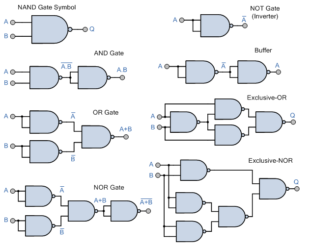

- Prirodno, dalji put razvoja omogucio je neka logicka kola koja su bila *programabilna*, tj. bilo je moguce na neki nacin im fleksibilno menjati funkciju koju daju na izlazu, tj. *programirati* njihov rad
- 1. Intel je izbacio prvi zvanican procesor - *4040*
- Procesor funkcionise tako sto obradjuje instrukcije i podatke - sve date u vidu niza nula i jedinica, i na kraju izbacuje neki rezultat obrade
- Ova jednostavna obrada podataka, uz prosirenje funkcionalnosti procesora dodavanjem dodatnih hardverskih komponenti (memorije, komunikacionih kanala, raznih drugih periferija) dovela je postepenim usloznjavanjem do savremenih racunara (PC-jeva, laptopova, smartphone-a, tableta, namenskih racunara ugradjenih u automobile, avione, rutere, modeme, set-top box-ove...)
- Danas sva "pametna" elektronika funkcionise tako sto je u RAM memoriju racunara ucitan neki program (niz nula i jedinica), koji predstavlja niz instrukcija i podataka kroz koji procesor prolazi, obradjujuci ih i izbacujuci rezultate

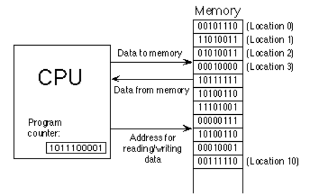

- **Vazno je zapamtiti**: procesor razume samo nule i jedinice. One za njega predstavljaju instrukcije (uputstva) kako da obradi podatke koji su mu dati (takodje u vidu nula i jedinica)
- Ovo cini vrlo nezgodnim pisanje iole kompleksnijeg programa, posto ljudi nisu navikli da razmisljaju na masinskom jeziku
- Zbog ovog problema, razvijen je prvi visi nivo iznad masinskog jezika - **assembly**
- Ovaj jezik cini skup od nekoliko jednostavnih, ljudski citljivih instrukcija (poput **add**, **sub**, **mul**...) koje **asembler** prevodi u masinske instrukcije (recimo, operacija sabiranja **add** je u nekom procesoru oznacena sa 0101, tj. procesor kad vidi osmobitnu instrukciju **0101 01 10**, on zna da operande 01b = 1d i 10b = 2d treba da sabere)
- **Note**: da li je racunar 32-bitni ili 64-bitni, sto je pitanje koje se cesto cuje, prosto znaci kolike instrukcije je procesor u mogucnosti da obradi. Primer gore pokazuje da je osmobitnom instrukcijom moguce pokriti, recimo, sabiranje do nekog broja. Slicno, prosirenjem instrukcije na 32 ili 64 bita, procesoru se omogucava baratanje sa vecim podacima sto povecava i brzinu rada. Svi savremeni racunari su 64-bitni
- Sada je programeru omoguceno da napise kod u assembly-ju koji ce potom asembler prevesti u masinski jezik koji ce procesor razumeti
- Na ovaj nacin dignut je nivo apstrakcije cime je olaksan rad jer se ne mora misliti o sitnicama, vec je moguce fokusirati se na logiku programa koji treba da se izvrsava na uredjaju
- Nakon assembly-ja razvijani su tzv. *visi programski jezici*, od kojih je najznacajniji **C**
- Visi programski jezici dalje dizu nivo apstrakcije, programera lisavaju razmisljanja o hardveru, i omogucavaju mu potpuno posvecivanje razvijanju algoritma

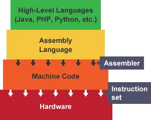

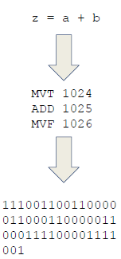

## 1.2 Kompajler vs interpreter

- **Kompajler** je program koji prolazi kroz izvorni kod i od njega pravi izvrsni fajl (fajl na masinskom jeziku koji procesor razume)
- Sve sto je dalje potrebno je da se ovaj fajl spakuje u memoriju i procesor moze krenuti da ga obradjuje instrukciju po instrukciju
- **Interpreter** svaku pojedinacnu liniju u izvornom kodu prevodi u masinski kod koji se izvrsava, pa se potom vraca na narednu liniju koju opet prevodi u masinski kod, itd.
- Kompajler je brzi od interpretera, ali znatno kompleksniji i manje fleksibilan

[figure not shown]

## 1.3 Sta je Python?

- Python je savremeni visi programski jezik, cija je sintaksa jako bliska nacinu na koji ljudi razmisljaju, a nivo apstrakcije je dignut daleko od hardvera
- Python je interpretiran jezik
- Veoma je mocan i vrlo cesto koriscen (scripting, machine learning, data science, backend web programiranje...)
- Svake godine Python je medju top 5 najpopularnijih programskih jezika, sto zbog svoje jednostavnosti, sto zbog stalnog unapredjivanja i pracenja savremenih trendova u programskim jezicima
- Odlicna dokumentacija
- Podrska velike programerske zajednice (svaki problem na koji naidjete moci cete da izguglate)

[figure not shown]

## 1.4 Python 2 vs Python 3

- Python 3 je novi standard, koji je dosao uz brojne izmene i unapredjenja u odnosu na prethodnu verziju
- Nije sasvim backward kompatibilan - Python 3 interpreter ne moze da izvrsava sve programe pisane Python 2 sintaksom (jer neke instrukcije vise nisu podrzane ili su izmenjene)
- Brojni programi su pisani na Python-u 2 koji je dugo postojao, te se stoga cesto vidja da su na nekom sistemu (Windows-u, Linux-u) instalirana oba
- Mi cemo se drzati novog standarda

## 1.5 Instaliranje Python-a

- Kako smo rekli, posto je Python interpretiran jezik, neophodno je da na racunaru na kom zelimo da pokrenemo neki Python program imamo instaliran Python interpreter - gotov program koji ce prolaziti liniju po liniju naseg koda, interpretirati je i izvrsavati na racunaru
- Najnoviji interpreter se moze skinuti sa zvanicnog sajta https://www.python.org/

[figure not shown]

- Pokrenite skinuti **exe** fajl
- Cekirajte obe opcije na dnu

[figure not shown]

- Install now
- Kad zavrsi - close

[figure not shown]

- Da proverimo je li Python instaliran, u Start-u trazimo **cmd**
- Kucamo

  ```
  python --version
  ```

[figure not shown]

## 1.6 Prvi Python program

- Ukoliko nije instaliran, instalirati Notepad++ (text editor koji ima razne dodatne funkcionalnosti, jako zgodan za citanje koda programskih jezika)
- Na desktopu napraviti folder sa svojim imenom
- U njemu napraviti tekstualni fajl i preimenovati ga u **proba.py**
- Otvoriti ga preko Notepad++-a i u njemu otkucati

  ```
  print("Moj prvi Python program!")
  ```

- Sacuvati preko Ctrl + S
- Otvoriti cmd iz Start-a
- U njemu se pozicionirati u folder na desktopu koriscenjem **cd** komande (change directory)

  ```
  > cd Desktop
  > cd Ime
  ```

- Pozvati Python interpreter i proslediti mu ime fajla koji smo sacuvali

  ```
  > python proba.py
  ```

[figure not shown]

- Python interpreter je uspesno pokrenuo nas program koji radi upravo ono sto se od njega ocekuje: ispisuje na ekran *"Moj prvi Python program!"*

## 1.7 Print funkcija

- Kao sto smo videli, *print* je komanda koja u terminal ispisuje tekst koji joj je prosledjen u zagradi
- Pored toga, *print* ce, u sustini ispisati bilo sta sto joj se stavi u zagrade
- Zadatak: napisati i pokrenuti program koji ce u terminalu ispisati (umesto xxxx godina svog rodjenja)

  ```
  Rodjen sam xxxx-e godine
  ```

```python
print("Rodjen sam", 1996, "-e godine")
```

```
Rodjen sam 1996 -e godine
```

## 1.8 Kako se to u stvarnosti radi?

- Kao sto smo videli, za ovako jednostavan program, ovo nije bilo tesko izvesti
- Medjutim, za kompleksnije programe, bilo bi zamlatno pisati u obican tekstualni fajl, zatim pozivati Python interpreter i u terminalu posmatrati izlaz programa
- Za ove potrebe razvijana su okruzenja za programiranje (tzv. **IDE** - integrated development environment), u kojima postoji polje za unos izvornog koda korisnickog programa, zatim jednostavno "play" dugme na koje se poziva interpreter koji izvrsava program, te i dodatne funkcionalnosti kao sto su debugger, syntax highlighter, linter itd. koji olaksavaju kucanje programa

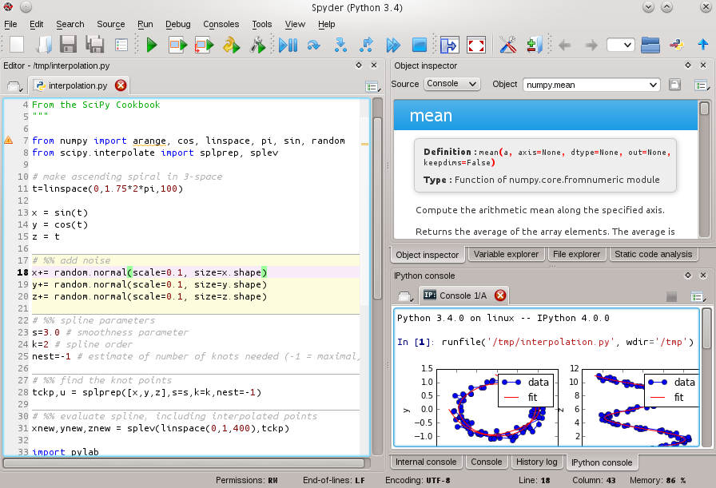

## 1.9 Google Colab

- Kako ne bismo gubili vreme na ucenje raznih alata koji se u realnosti vrlo retko koriste, preci cemo na ono sto se trenutno najcesce koristi za Python development - **Python notebook**
- **Jupyter notebook** je web aplikacija koja vam omogucava da u browser-u kucate i izvrsavate Python program, kao i da usput hvatate beleske u vidu sveske (notebook-a)
- Google je napravio svoju verziju ove aplikacije - Google Colab https://colab.research.google.com/
- Colab cemo koristiti nadalje, jer on sprecava zamlacivanje sa instalacijom dodatnih biblioteka koje se eventualno koriste i vrlo je zgodan za koriscenje kada se jednom upoznate sa njim
- Ako u nastavku kursa bude potrebe, instaliracemo neki IDE na racunare, kako bismo demonstrirali rad

[figure not shown]

- Kada otvorite Colab, idite na File->New i kreirajte novu svesku koju cete nazvati **1_cas.ipynb**
- Notebook-ovi kreirani preko Google Colab-a automatski se smestaju na Google Drive povezan sa @code.edu.rs nalogom koji vam je napravljen
- Na taj nacin cete tamo uvek moci da nadjete svoje beleske, a i moje sveske koje share-ujem sa vama ce biti tamo

## 1.10 Print funkcija (u novom izdanju)

- Sveska je organizovana u tzv. celije (cells) koje mogu biti code i text tipa
- Text tip podrzava opisni (markdown) jezik, slican HTML-u (ali jednostavniji i sa manje mogucnosti), koji vam omogucava da lepo pisete beleske (boldujete, nabrajate, ubacujete slike...)
- Code tip je celija u koju se pise Python kod
- U prvu celiju koja vam je izasla ukucajte

  ```
  print("Moj drugi Python program!")
  ```

- Pokrenite klikom na play na levoj strani celije (ili, Ctrl + Enter)

[figure not shown]

## 1.11 Komentari, navodnici, tipovi podataka, input

- Svi jezici omogucavaju programeru da pored samog koda pise i komentare uz kod u samom izvornom kodu
- Komentari se ne kompajliraju niti interpretiraju - oni su samo tu kako bi programeru pomogli da se snadje u kodu i ostavlja beleske

```python
# Ovo je komentar. On se ne interpretira. Pocinje tarabom na pocetku reda
# Iza tarabe moze stajati bilo sta dnoasndioasidd+saddmsl,d.a1+

a = 3 + 1   # Ovo je komentar uz naredbu levo, koja kaze da se u promenljivu a smesti rezultat 3+1

# Naredba ce biti interpretirana, a njen rezultat mozemo videti sa

print(a)    # Sada printujemo vrednost promenljive a, ne neki fiksan tekst
```

```
4
```

```python
"""
Ovo ovde je viselinijski komentar.
On pocinje trostrukim duplim navodnicima i istim se zavrsava.
Proizvoljno mnogo linija je moguce ovako otkucati, sto se cesto
koristi kod opisa funkcija
"""
```

- U Pythonu su i jednostruki i dvostruki navodnici potpuno validni
- Fora je samo otvarati i zatvarati ono pod navodnicima istim tipom navodnika, tj. ako nesto otvorite dvostrukim, zatvorite ga dvostrukim navodnicima. Slicno za jednostruke

```python
a = 'Ovo je string sa jednostrukim navodnicima'
b = "Ovo je string sa dvostrukim"
# Nema nikakve razlike u ovim stringovima, a ovakvo resenje je dato kako bi se moglo reci
c = "Sad' nemam problema sa apostrofima"
d = 'Niti sa citatima: "Citat"'
# Dogod je sve pravilno otvoreno i zatvoreno

print(a)
print(b)
print(c)
print(d)
```

[output not shown]

- **Tip podataka** je atribut koji procesoru govori na koji nacin da rastumaci niz nula i jedinica koji vidi
- **Podsetnik**: procesor barata samo sa nulama i jedinicama. On ne zna sta predstavljaju podaci u instrukciji 0101 01 10
- Stoga se podacima pridruzuju tipovi kako bi se podaci smisleno obradjivali
- Neki osnovni tipovi u Python-u su

```python
a = 1               # Integer (celobrojni tip, koristi se za smestanje celih brojeva)
b = 3.14            # Floating point (decimalni tip, za smestanje brojeva sa zarezom)
c = "neka recenica" # String (tip za smestanje niza karaktera)
```

- Moguce je napraviti i proizvoljan tip, koji ce da sadrzi sta god nam treba

```python
class Osoba:
    self.name = "Petar"
    self.age = 30
    self.address = "Knez Mihailova 1"
```

- Pored izbacivanja rezultata na ekran, moguce je i od korisnika preuzeti neki unos

```python
# Koriscenjem funkcije input od korisnika cemo traziti da unese svoje ime
ime = input("Unesite svoje ime: ")
# Sada je u promenljivu 'ime' smesteno ono sto je korisnik uneo
print("Vase ime je", ime)
```

```
Unesite svoje ime: Kristijan
Vase ime je Kristijan
```

## 1.12 Kako guglati?

- Svaki problem koji vas usput zadesi najlakse cete resiti guglanjem
- Vrlo verovatno je neko pre vas naisao na taj problem i vrlo verovatno ga je resio

```python
print("Ovo ce da pukne"
```

```
  File "<ipython-input-9-5003c93872d9>", line 1
    print("Ovo ce da pukne"
                           ^
SyntaxError: unexpected EOF while parsing
```

- Guglate doslovce gresku koju vam je Python izbacio i trazite sta su ljudi pisali o tome

[figure not shown]

- Ubrzo cete zakljuciti da ste zaboravili da zatvorite zagradu
- Najcesce cete resenje naci na www.stackoverflow.com, ali i svasta drugo sto iskoci guglanjem moze biti od pomoci

## 1.13 Zadaci za rad na casu

1. Napisati program koji od korisnika trazi unos imena, prezimena i broja godina, i zatim iste lepo ispisuje na ekran
2. Napisati program koji za unete stranice pravougaonika a i b racuna njegov obim i povrsinu i to lepo ispisuje na ekran

## 1.14 Domaci

1. Proci kroz sve primere sa casa
2. Napisati program koji simulira rad jednostavnog kalkulatora: od korisnika se trazi da unese dva broja, a potom se na ekran ispisuje rezultat sabiranja, oduzimanja, mnozenja i deljenja ova dva broja